# Aula 3 - Organização de Dados, Teste t e Mapas

# 11. Conferir valores ausentes

Após unir tabelas, é sempre bom verificar se ainda existem valores ausentes nas variáveis principais. Isso ajuda a decidir como resumir e analisar os dados.

```r
dados_experimento_geo |>
  summarise(
    n_na_severity = sum(is.na(severity)),
    n_na_yield = sum(is.na(yield_kg_ha)),
    n_na_state = sum(is.na(state)),
    n_na_altitude = sum(is.na(altitude_m))
  )
```

| n_na_severity | n_na_yield | n_na_state | n_na_altitude |
| --- | --- | --- | --- |
| 2 | 1 | 0 | 0 |

# 12. Resumos descritivos iniciais

Antes de qualquer teste inferencial, é recomendável resumir os dados. Vamos calcular as médias de severidade e produtividade por tratamento e por ano.

```r
resumo_tratamento_ano <- dados_experimento_geo |>
  group_by(year, treatment) |>
  summarise(
    media_severity = mean(severity, na.rm = TRUE),
    media_yield = mean(yield_kg_ha, na.rm = TRUE),
    n = n(),
    .groups = "drop"
  )

resumo_tratamento_ano
```

| year | treatment | media_severity | media_yield | n |
| --- | --- | --- | --- | --- |
| 2022 | Control | 36.75000 | 3350.000 | 4 |
| 2022 | Fungicide | 15.00000 | 4075.000 | 4 |
| 2023 | Control | 38.75000 | 3300.000 | 4 |
| 2023 | Fungicide | 16.25000 | 4025.000 | 4 |
| 2024 | Control | 38.00000 | 3375.000 | 4 |
| 2024 | Fungicide | 14.66667 | 4096.667 | 4 |

Também podemos resumir apenas por tratamento, considerando todos os anos em conjunto.

```r
resumo_tratamento <- dados_experimento_geo |>
  group_by(treatment) |>
  summarise(
    media_severity = mean(severity, na.rm = TRUE),
    dp_severity = sd(severity, na.rm = TRUE),
    media_yield = mean(yield_kg_ha, na.rm = TRUE),
    dp_yield = sd(yield_kg_ha, na.rm = TRUE),
    n = n(),
    .groups = "drop"
  )

resumo_tratamento
```

| treatment | media_severity | dp_severity | media_yield | dp_yield | n |
| --- | --- | --- | --- | --- | --- |
| Control | 37.81818 | 4.166970 | 3341.667 | 120.59197 | 12 |
| Fungicide | 15.36364 | 2.656039 | 4062.727 | 98.80191 | 12 |

# 13. Comparação de médias com o teste *t*

Agora vamos comparar as médias de produtividade entre os dois tratamentos: `Control` e `Fungicide`.

O teste *t* para duas amostras independentes é um procedimento inferencial usado para avaliar se a diferença entre duas médias amostrais é grande o suficiente para sugerir que as médias populacionais também diferem.

## 13.1 Hipóteses do teste

Ao aplicar o teste *t*, formulamos duas hipóteses:

- **Hipótese nula** ($H_0$): as médias populacionais são iguais
  $$H_0 : \mu_1 = \mu_2$$
- **Hipótese alternativa** ($H_1$): as médias populacionais são diferentes
  $$H_1 : \mu_1 \neq \mu_2$$

No nosso exemplo, queremos comparar a produtividade média entre os tratamentos `Control` e `Fungicide`.

## 13.2 Estatística do teste

A estatística *t* compara a diferença observada entre médias com a variabilidade dessa diferença.

Na forma clássica do teste com variâncias assumidas como iguais, a estatística é dada por:

$$t = \frac{\bar{x}_1 - \bar{x}_2}{s_p\sqrt{\frac{1}{n_1} + \frac{1}{n_2}}}$$

em que:

- $\bar{x}_1$ e $\bar{x}_2$ são as médias amostrais;
- $n_1$ e $n_2$ são os tamanhos das amostras;
- $s_p$ é o desvio-padrão combinado (*pooled standard deviation*), calculado por:

$$s_p = \sqrt{\frac{(n_1 - 1)s_1^2 + (n_2 - 1)s_2^2}{n_1 + n_2 - 2}}$$

em que:

- $s_1^2$ e $s_2^2$ são as variâncias amostrais dos dois grupos.

Na prática, o R calcula automaticamente a estatística *t* e o *p*-valor quando usamos `t.test()`. O mais importante neste momento é entender a lógica: quanto maior a diferença entre médias em relação à variabilidade dos dados, mais extremo tende a ser o valor de *t*.

## 13.3 Ajustar o teste no R

Vamos aplicar o teste *t* à produtividade.

```r
teste_t_yield <- t.test(yield_kg_ha ~ treatment, data = dados_experimento_geo)
teste_t_yield
```

```
    Welch Two Sample t-test

data:  yield_kg_ha by treatment
t = -15.737, df = 20.762, p-value = 5.186e-13
alternative hypothesis: true difference in means between group Control and group Fungicide is not equal to 0
95 percent confidence interval:
 -816.4113 -625.7099
sample estimates:
  mean in group Control mean in group Fungicide
               3341.667                4062.727
```

A saída mostra, entre outras informações:

- o valor da estatística *t*;
- os graus de liberdade;
- o *p*-valor;
- as médias estimadas dos dois grupos.

Também podemos organizar essa saída em formato de tabela com `broom::tidy()`.

```r
resultado_tidy <- tidy(teste_t_yield)
resultado_tidy
```

| estimate | estimate1 | estimate2 | statistic | p.value | parameter | conf.low | conf.high | method | alternative |
| --- | --- | --- | --- | --- | --- | --- | --- | --- | --- |
| -721.0606 | 3341.667 | 4062.727 | -15.73743 | 5.186022e-13 | 20.7621 | -816.4113 | -625.7099 | Welch Two Sample t-test | two.sided |

# 14. Interpretar o valor de *t* e o *p*-valor

O valor de *t* indica quantos “erros-padrão” separam a diferença observada entre médias do valor esperado sob a hipótese nula. Quanto mais distante de zero estiver esse valor, maior a evidência contra $H_0$.

O *p*-valor representa a probabilidade de observar um valor de *t* tão extremo quanto o obtido, ou mais extremo, caso a hipótese nula seja verdadeira.

Se o *p*-valor for pequeno, consideramos que os dados fornecem evidência para rejeitar a hipótese nula.

Vamos extrair os valores de interesse para usar nos gráficos seguintes.

```r
t_observado <- unname(teste_t_yield$statistic)
gl_observado <- unname(teste_t_yield$parameter)
p_observado <- unname(teste_t_yield$p.value)

t_observado
```

```
[1] -15.73743
```

```r
gl_observado
```

```
[1] 20.7621
```

```r
p_observado
```

```
[1] 5.186022e-13
```

# 15. Visualizar a estatística *t* na distribuição do teste

Uma forma didática de entender o teste é visualizar onde o valor observado de *t* cai na distribuição *t* de Student sob a hipótese nula.

No gráfico abaixo:

- a curva representa a distribuição *t*;
- a linha vertical mostra o valor observado de *t*;
- a área sombreada representa a região associada ao *p*-valor.

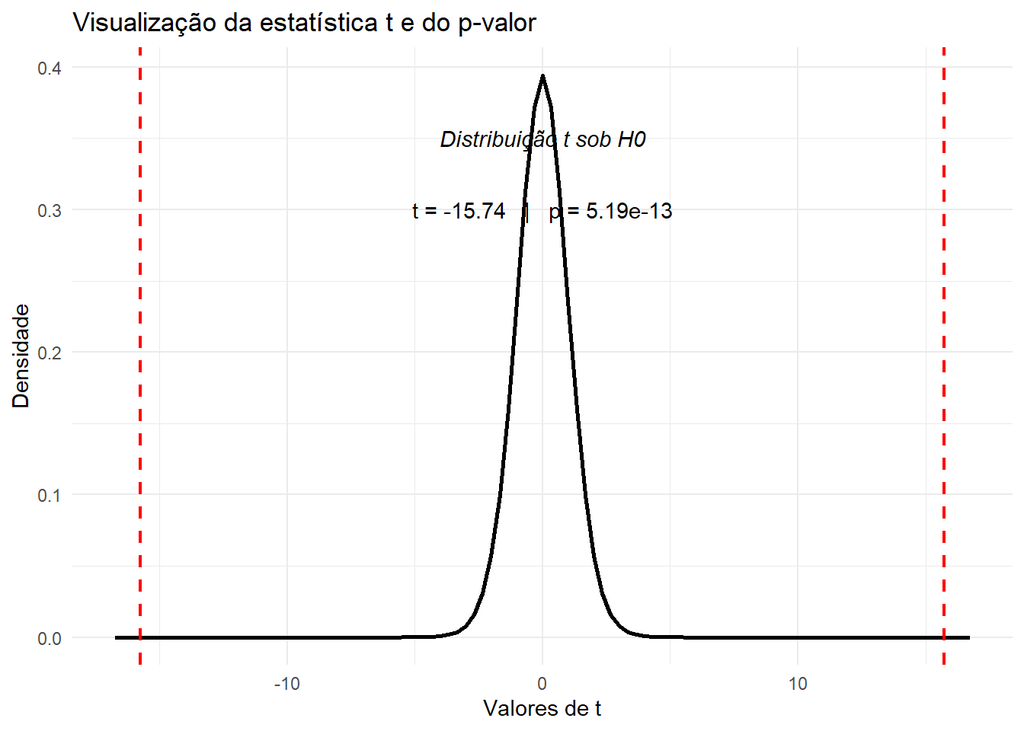

```r
limite_x <- max(4, abs(t_observado) + 1)

ggplot(data.frame(x = c(-limite_x, limite_x)), aes(x)) +
  stat_function(
    fun = dt,
    args = list(df = gl_observado),
    linewidth = 1
  ) +
  geom_vline(
    xintercept = c(-abs(t_observado), abs(t_observado)),
    colour = "red",
    linetype = "dashed",
    linewidth = 0.8
  ) +
  stat_function(
    fun = dt,
    args = list(df = gl_observado),
    xlim = c(-limite_x, -abs(t_observado)),
    geom = "area",
    fill = "red",
    alpha = 0.25
  ) +
  stat_function(
    fun = dt,
    args = list(df = gl_observado),
    xlim = c(abs(t_observado), limite_x),
    geom = "area",
    fill = "red",
    alpha = 0.25
  ) +
  annotate(
    "text",
    x = 0,
    y = 0.35,
    label = "Distribuição t sob H0",
    fontface = "italic"
  ) +
  annotate(
    "text",
    x = 0,
    y = 0.30,
    label = paste0("t = ", round(t_observado, 2),
                   "   |   p = ", signif(p_observado, 3))
  ) +
  labs(
    title = "Visualização da estatística t e do p-valor",
    x = "Valores de t",
    y = "Densidade"
  ) +
  theme_minimal()
```

# 16. Construir um gráfico de produtividade anotado com o teste *t*

Agora que já ajustamos e interpretamos o teste, podemos construir um gráfico de produtividade por tratamento e acrescentar o resultado estatístico ao painel.

A ordem importa: primeiro fazemos a análise, depois usamos seu resultado para enriquecer a visualização.

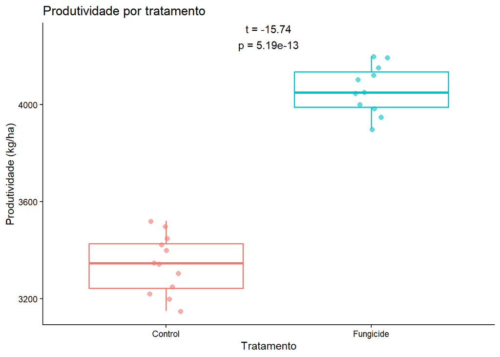

```r
rotulo_teste <- paste0(
  "t = ", round(t_observado, 2), "\n",
  "p = ", signif(p_observado, 3)
)

grafico_yield <- dados_experimento_geo |>
  ggplot(aes(x = treatment, y = yield_kg_ha, color = treatment)) +
  geom_boxplot(outlier.shape = NA, linewidth = 0.6) +
  geom_jitter(width = 0.08, alpha = 0.6, size = 2) +
  annotate(
    geom = "text",
    x = 1.5,
    y = max(dados_experimento_geo$yield_kg_ha, na.rm = TRUE) + 80,
    label = rotulo_teste
  ) +
  labs(
    x = "Tratamento",
    y = "Produtividade (kg/ha)",
    title = "Produtividade por tratamento"
  ) +
  theme_classic() +
  theme(legend.position = "none")

grafico_yield
```

Se desejado, o gráfico pode ser salvo em arquivo.

```r
# ggsave("grafico_produtividade_tratamento.png", grafico_yield, width = 6, height = 5, bg = "white")
```

# 17. Considerações finais

Esta aula mostrou um fluxo muito comum em análise de dados experimentais:

1. importar múltiplos arquivos;
2. inspecionar a estrutura das tabelas;
3. padronizar nomes e categorias;
4. unir arquivos anuais;
5. adicionar informações auxiliares com `join`;
6. resumir os dados de forma descritiva;
7. comparar tratamentos com um teste inferencial;
8. representar a análise em um gráfico final.

Esse fluxo reforça uma ideia importante: uma boa análise não começa no teste estatístico. Ela começa na organização da base e no entendimento claro do que cada variável representa.

# 18. Exercícios sugeridos

1. Calcule a severidade média por local e por tratamento.
2. Construa um gráfico de severidade por tratamento.
3. Aplique um teste *t* para comparar a severidade média entre os tratamentos.
4. Verifique se o resultado do teste para severidade é consistente com o gráfico.
5. Modifique o código do gráfico final para anotar o teste da severidade em vez do teste da produtividade.

# 19. Complemento: Exploração Visual Extra

Uma das grandes vantagens do pacote `ggplot2` é a facilidade em criar gráficos que revelam a relação entre as variáveis da nossa base.

## 19.1. Dispersão entre variáveis

Podemos, por exemplo, visualizar a relação direta entre a Severidade e a Produtividade. Geralmente, esperamos que quanto maior a severidade de uma doença na planta, menor seja a sua produtividade (correlação negativa).

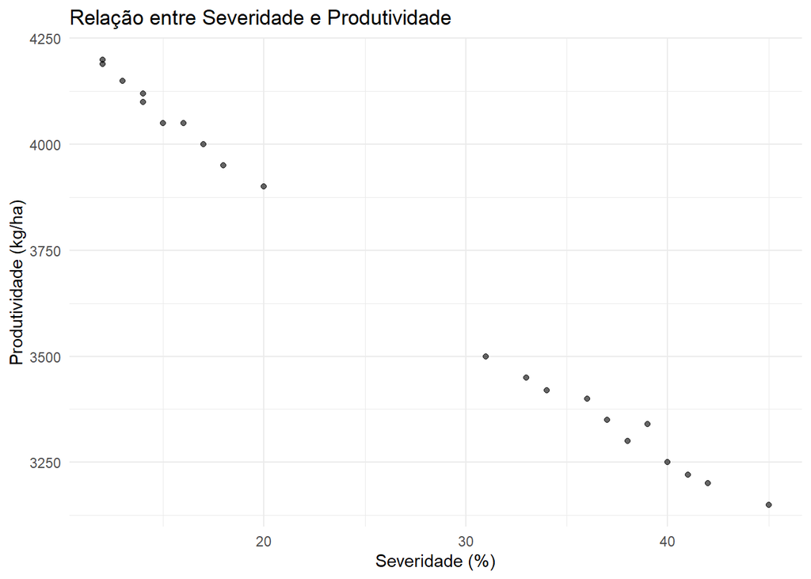

```r
dados_experimento_geo |>
  ggplot(aes(x = severity, y = yield_kg_ha)) +
  geom_point(alpha = 0.6) +
  theme_minimal() +
  labs(
    x = "Severidade (%)",
    y = "Produtividade (kg/ha)",
    title = "Relação entre Severidade e Produtividade"
  )
```

## 19.2. Painéis múltiplos (`facet_grid`)

Para análises de múltiplos anos e locais, podemos dividir nossos gráficos em facetas (painéis). O código abaixo permite visualizar se o efeito dos tratamentos na severidade muda a depender do Ano e da Localidade.

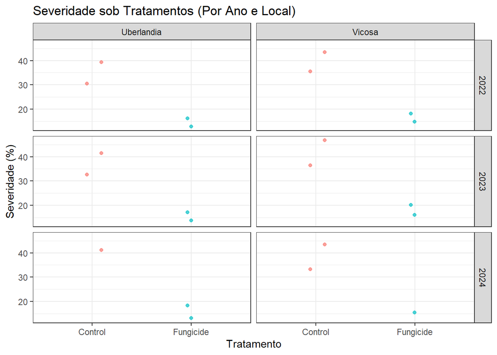

```r
dados_experimento_geo |>
  ggplot(aes(x = treatment, y = severity, color = treatment)) +
  geom_jitter(width = 0.1, alpha = 0.7) +
  facet_grid(year ~ location) + # Separa as linhas por Ano e colunas por Local
  theme_bw() +
  labs(
    x = "Tratamento",
    y = "Severidade (%)",
    title = "Severidade sob Tratamentos (Por Ano e Local)"
  ) +
  theme(legend.position = "none")
```

# 20. Bônus: Trabalhando com Dados Espaciais e Mapas

Para trabalhar com mapas no R, utilizamos o formato padrão `sf` (Simple Features) e pacotes auxiliares de dados como o `rnaturalearth`.

## 20.1. Carregando pacotes essenciais para mapas

```r
library(sf) # O pacote chave para trabalhar com objetos espaciais
library(rnaturalearth) # Disponibiliza mapas mundiais prontos (shapes)
library(rnaturalearthdata)
library(ggthemes) # Para temas específicos de mapas
library(ggrepel) # Para evitar que as legendas de texto fiquem sobrepostas
library(ggspatial) # Adiciona itens cartográficos (ex: flecha de norte e escala)
```

## 20.2. Construindo um Mapa da Etiópia (Exemplo didático)

Vamos criar o mapa de uma localização específica. Para isso, importamos uma base global que contém a localização de diversas fazendas de café acometidas por ferrugem.

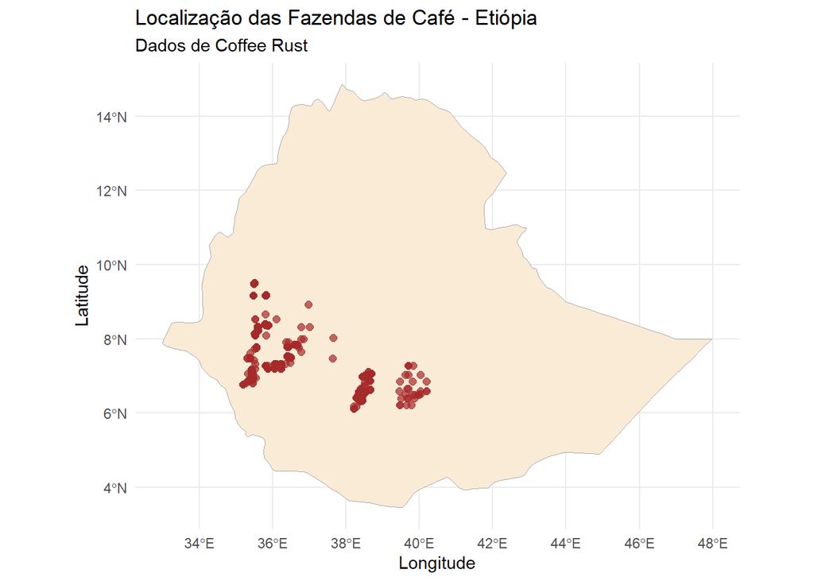

```r
dados_cafe <- gsheet2tbl("[https://docs.google.com/spreadsheets/d/1bq2N19DcZdtax2fQW9OHSGMR0X2__Z9T/edit?gid=1871397229#gid=1871397229](https://docs.google.com/spreadsheets/d/1bq2N19DcZdtax2fQW9OHSGMR0X2__Z9T/edit?gid=1871397229#gid=1871397229)")

# 1. Faz o download do formato vetorial ('sf') do país desejado.
ethiopia_map <- ne_countries(scale = "medium", country = "ethiopia", returnclass = "sf")

# 2. Plota o shape do país e os pontos de coordenadas acima dele.
ggplot() +
  geom_sf(data = ethiopia_map, fill = "antiquewhite", color = "darkgrey") +
  geom_point(data = dados_cafe, aes(x = lon, y = lat), color = "brown", size = 2, alpha = 0.7) +
  theme_minimal() +
  labs(
    title = "Localização das Fazendas de Café - Etiópia",
    subtitle = "Dados de Coffee Rust",
    x = "Longitude",
    y = "Latitude"
  ) +
  coord_sf() # Exclusivo para garantir que a proporção geográfica do mapa seja correta
```

## 20.3. Desenhando o Mapa do Brasil com Capitais

Também podemos construir mapas estaduais usando o R! Para o Brasil, precisaremos baixar detalhes da subunidade (estados). Criaremos um data frame manual com as coordenadas das capitais e traçaremos o país inteiro.

*Dica: Caso dê erro de pacote ao renderizar, rode `install.packages("rnaturalearthhires", repos = "https://ropensci.r-universe.dev")` no console antes de continuar.*

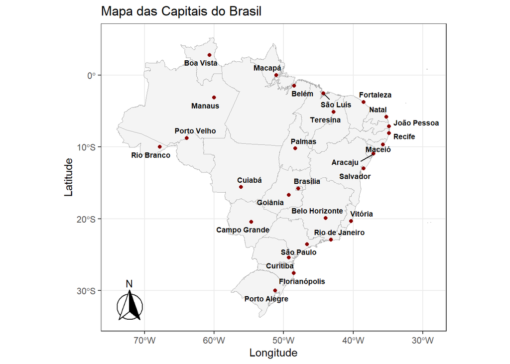

```r
# Criando o dataframe com todas as capitais brasileiras
coordenadas <- data.frame(
  site = c(
    "Aracaju", "Belém", "Belo Horizonte", "Boa Vista", "Brasília",
    "Campo Grande", "Cuiabá", "Curitiba", "Florianópolis", "Fortaleza",
    "Goiânia", "João Pessoa", "Macapá", "Maceió", "Manaus",
    "Natal", "Palmas", "Porto Alegre", "Porto Velho", "Recife",
    "Rio Branco", "Rio de Janeiro", "Salvador", "São Luís", "São Paulo",
    "Teresina", "Vitória"
  ),
  lat = c(
    -10.9472, -1.4558, -19.9167, 2.8235, -15.7942,
    -20.4427, -15.6010, -25.4284, -27.5969, -3.7319,
    -16.6869, -7.1153, 0.0347, -9.6662, -3.1190,
    -5.7944, -10.2128, -30.0346, -8.7612, -8.0578,
    -9.9747, -22.9068, -12.9714, -2.5307, -23.5505,
    -5.0892, -20.3155
  ),
  lon = c(
    -37.0731, -48.4902, -43.9345, -60.6758, -47.8822,
    -54.6464, -56.0974, -49.2733, -48.5495, -38.5267,
    -49.2648, -34.8611, -51.0666, -35.7353, -60.0217,
    -35.2110, -48.3243, -51.2177, -63.9039, -34.8778,
    -67.8101, -43.1729, -38.5014, -44.3068, -46.6333,
    -42.8016, -40.3128
  )
)

# 1. Faz download da divisão estadual brasileira
brazil_map <- ne_states(country = "brazil", returnclass = "sf")

# 2. Plotagem do mapa e customização
ggplot() +
  geom_sf(data = brazil_map, fill = "#f4f4f4", color = "darkgray") +

  # Adiciona as coordenadas no mapa (geom_point mapeia os pontos x/y)
  geom_point(data = coordenadas, aes(x = lon, y = lat), color = "darkred", size = 1.5) +

  # Adiciona o nome das capitais sem que os textos se cruzem ou engulam os pontos
  geom_text_repel(data = coordenadas, aes(x = lon, y = lat, label = site), size = 2.5, fontface = "bold") +

  # Adiciona estilo de mapa, flecha do norte
  annotation_north_arrow(location = "bl", which_north = "true",
                         style = north_arrow_fancy_orienteering) +
  theme_bw() +
  labs(
    title = "Mapa das Capitais do Brasil",
    x = "Longitude",
    y = "Latitude"
  )
```